# Clasificación automática de reseñas de películas

En este trabajo, se busca crear un modelo para clasificar automáticamente reseñas de películas según su tipo (positivas o negativas). Se aplican cuatro técnicas de machine learning y se analizan distintos escenarios con el propósito de alcanzar la mayor precisión posible.

## 1) Recolección de datos

En esta sección, se lleva a cabo la recolección de datos. Se recurre a [IMDb](https://www.imdb.com/) para obtener reseñas de películas escritas por usuarios. La recolección de datos se llevó a cabo el 16 de octubre de 2023.

Primero se configura [Selenium](https://www.selenium.dev/) para automatizar la tarea de obtener reseñas de IMDb.

```python
#Importar bibliotecas necesarias
from selenium import webdriver
import helium as he
import pandas as pd
pd.options.mode.chained_assignment = None
import warnings
warnings.filterwarnings('ignore')

#Configuración inicial
driver_path = ".../chromedriver.exe"
brave_path = ".../brave.exe"
option = webdriver.ChromeOptions()
option.binary_location = brave_path
```

```python
#Iniciar el navegador
driver = webdriver.Chrome(executable_path=driver_path, chrome_options=option)
he.set_driver(driver)

#Ir a IMDb
imdb_full = "https://www.imdb.com/chart/moviemeter/"
he.go_to(imdb_full)

#Buscar enlaces de películas
elementos = driver.find_elements_by_css_selector(".ipc-title-link-wrapper")
links = []
for elem in elementos[0:100]:
    link = elem.get_attribute("href")
    links.append(link)

#Cargar reseñas
paginas_reviews = "reviews?sort=curated&dir=desc&ratingFilter=" #Enlace para ver reseñas
reviews_positivas = []
reviews_negativas = []

for link in links:
    pagina = link.split("?")[0] #Enlace limpio
    numeros = ["1","2","3","8","9","10"] #Calificación de la película
    for star in numeros:
        he.go_to(pagina + paginas_reviews + star)

        #Abrir reseñas
        clickeables = driver.find_elements_by_class_name("expander-icon-wrapper.spoiler-warning__control")
        for clickeable in clickeables:
            clickeable.click()

        #Copiar reseñas
        elem_reviews = driver.find_elements_by_css_selector(".text.show-more__control")
        review_nueva = []
        i = 0
        while i < len(elem_reviews) and len(review_nueva)<5:
            if elem_reviews[i].text!="": #No se incluyen reseñas vacías
                review_nueva.append(elem_reviews[i].text)
            i += 1
        if int(star)<6:
            reviews_negativas.extend(review_nueva)
        else:
            reviews_positivas.extend(review_nueva)

#Cerrar el navegador
he.kill_browser()
```

Se convierten las reseñas recolectadas a dataframe y se guardan en formato .xlsx.

```python
df1 = pd.DataFrame(reviews_negativas)
df1.to_excel('reviews_negativas.xlsx')
df2 = pd.DataFrame(reviews_positivas)
df2.to_excel('reviews_positivas.xlsx')
```

## 2) Preprocesamiento

En esta sección se preparan los datos para su posterior análisis.

```python
#Importar bibliotecas necesarias
import matplotlib.pyplot as plt
import re
from nltk.corpus import stopwords
from nltk.stem import WordNetLemmatizer

#Cargar datos recolectados
datos_negativas = pd.read_excel(r'D:/Python/Textos/reviews_negativas.xlsx')
datos_positivas = pd.read_excel(r'D:/Python/Textos/reviews_positivas.xlsx')
```

A cada reseña, se le añade una etiqueta ("positiva" o "negativa") y un identificador. Las reseñas etiquetadas son luego guardadas en un único conjunto de datos.

```python
datos_negativas['tipo'] = 'negativa'
datos_positivas ['tipo'] = 'positiva'

#Asignarle un identificador a cada reseña
for numero in range(0, len(datos_positivas) ):
    datos_positivas.id[numero] = datos_positivas.id[numero] + len(datos_negativas)
    pass

#Fusionar ambos conjuntos
datos = pd.concat([datos_negativas, datos_positivas], ignore_index=True)
```

### Análisis exploratorio

Se revisa la presencia de valores perdidos en el conjunto de datos. Como se puede observar, no hubo ninguna reseña vacía.

```python
datos["texto"].isna().sum()
```

```
0
```

Se realiza un gráfico de barras para cada reseña según su tipo. Se puede ver que la proporción de reseñas positivas y negativas fue similar, aunque estas últimas fueron ligeramente más numerosas.

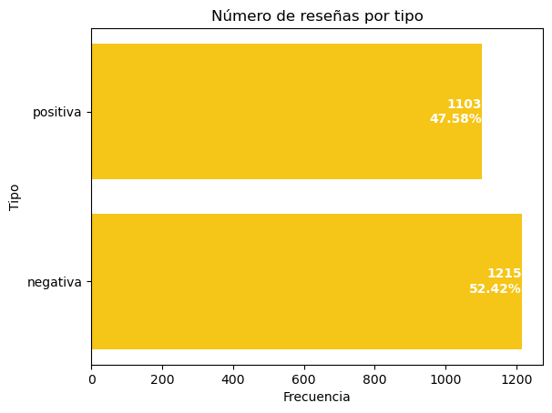

```python
plt.barh(datos['tipo'].unique(),
        datos['tipo'].value_counts(),
        color="#f5c518",
        )

for i in range(len(datos['tipo'].unique())):
        plt.text(datos['tipo'].value_counts()[i],
                 i,
                 str(datos['tipo'].value_counts()[i])
                     + "\n"
                     + str( round(datos['tipo'].value_counts()[i] / len(datos) * 100 ,2))
                     + "%",
                 ha='right', va='center',
                 color="white", weight='bold'
                 )

plt.title('Número de reseñas por tipo')
plt.xlabel('Frecuencia')
plt.ylabel('Tipo')
```

### Loop de preprocesamiento

Para cada reseña en el conjunto de datos, se realizan una serie de tareas conocidas como **preprocesamiento**. Estas incluyen pasar el texto a minúsculas, eliminar palabras vacías (*stopwords*) y lematizar las palabras. Una vez hecho esto, el texto procesado es añadido al conjunto de datos.

```python
text = list(datos['texto'])

lemmatizer = WordNetLemmatizer() #Lematizador

texto_limpio = []

for i in range(len(text)):

    r = re.sub('[^a-zA-Z]', ' ', text[i]) #Minúsculas
    r = r.lower()

    r = r.split() #Tokenizar (palabras)

    r = [word for word in r if word not in stopwords.words('english')] #Eliminar stopwords

    r = [lemmatizer.lemmatize(word) for word in r] #Lematización

    r = ' '.join(r) #Añadir a lista
    texto_limpio .append(r)


datos['texto_limpio'] = texto_limpio #Añadir a datset

#Guardar dataset
datos.to_csv("datos.csv", sep=',', index=False, encoding='utf-8')
```

## 3) Tokenización

La segmentación (o *tokenización*) de un texto es el proceso por el cual este es dividido en unidades menores, llamadas *tókenes*. Un token puede ser un carácter, una palabra o un conjunto de palabras, como se verá en esta sección.

```python
#Importar bibliotecas necesarias
import nltk
from collections import Counter
from sklearn.feature_extraction.text import CountVectorizer
from sklearn.feature_extraction.text import TfidfVectorizer
from wordcloud import WordCloud
import matplotlib.pyplot as plt
import networkx as nx
import scipy.sparse

#Cargar datos
datos = pd.read_csv(r'D:/Python/Textos/datos.csv')

#Dividir en positivo o negativo
datos_positivas = datos[datos['tipo'] == 'positiva']
texto_positivo = ' '.join(datos_positivas['texto_limpio'])
datos_negativas = datos[datos['tipo'] == 'negativa']
texto_negativo = ' '.join(datos_negativas['texto_limpio'])
```

### Unigramas

Un n-grama es una secuencia de *n* palabras consecutivas. En el caso particular cuando $n=1$, se denominan **unigramas**. A continuación, se grafican las palabras más frecuentes para las reseñas positivas y negativas.

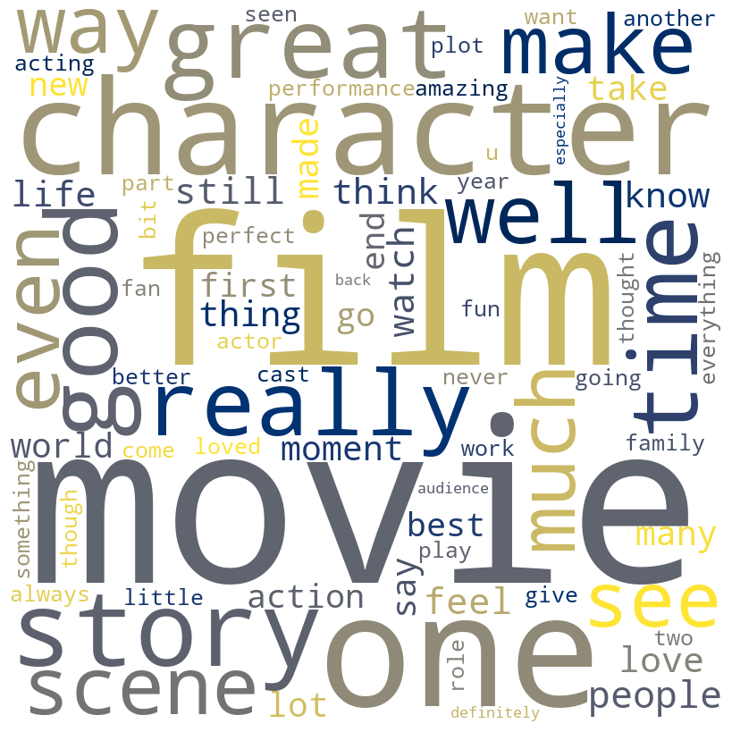

```python
#Nubes de palabras - Frecuencia de términos
nube_postivos = WordCloud(width = 800, height = 800,
                background_color ='white',
                colormap='cividis',
                max_words = 75,
                min_font_size = 10).generate(texto_positivo)

plt.figure(figsize = (8, 8), facecolor = None)
plt.imshow(nube_postivos)
plt.axis("off")
plt.tight_layout(pad = 0)
plt.show()
```

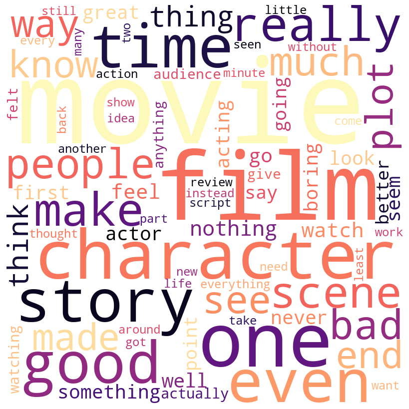

```python
#Nubes de palabras - Frecuencia de términos
nube_negativos = WordCloud(width = 800, height = 800,
                background_color ='white',
                colormap='magma',
                max_words = 75,
                min_font_size = 10).generate(texto_negativo)

plt.figure(figsize = (8, 8), facecolor = None)
plt.imshow(nube_negativos)
plt.axis("off")
plt.tight_layout(pad = 0)
plt.show()
```

### Unigramas con TF-IDF

En lugar de calcular la frecuencia absoluta de cada palabra (también llamada **frecuencia de términos**), es posible calcular una medida llamada frecuencia de término – frecuencia inversa de documento (**TF-IDF**). Esta estadística le asigna mayores ponderaciones a aquellos términos que aparezcan con mucha frecuencia pero en un número reducido de documentos. En otras palabras, intenta darle un mayor peso a los términos más representativos de cada documento.

El siguiente código calcula los valores de TF-IDF para reseñas positivas y negativas y crea un conjunto de datos con las palabras ordenadas de mayor a menor valor.

```python
#Unigramas más frecuentes
unigramas_positivos = Counter(nltk.word_tokenize(texto_positivo))
unigramas_negativos = Counter(nltk.word_tokenize(texto_negativo))

#Matrices con TF-IDF
tfidf_nube = TfidfVectorizer(smooth_idf=False, norm=None)
texto_corpus = [texto_negativo,texto_positivo]
matriz_nube = tfidf_nube.fit_transform(texto_corpus)

#Dataset
unigramas_positivos_df = pd.DataFrame.from_dict(unigramas_positivos, orient='index').reset_index().rename(columns={'index':'unigrama', 0:'valor'})
unigramas_negativos_df = pd.DataFrame.from_dict(unigramas_negativos, orient='index').reset_index().rename(columns={'index':'unigrama', 0:'valor'})

idf_full = pd.DataFrame({
    'unigrama': tfidf_nube.get_feature_names_out(),
    'idf': abs(1 - tfidf_nube.idf_)
})

idf_positivos = pd.merge(idf_full, unigramas_positivos_df, on='unigrama', how='right')
idf_negativos = pd.merge(idf_full, unigramas_negativos_df, on='unigrama', how='right')
idf_positivos["tfidf"] = idf_positivos["idf"]*idf_positivos["valor"]
idf_negativos["tfidf"] = idf_negativos["idf"]*idf_negativos["valor"]
```

Similar a lo hecho ateriormente, se grafican las palabras con mayores valores de TF-IDF para las reseñas positivas y negativas.

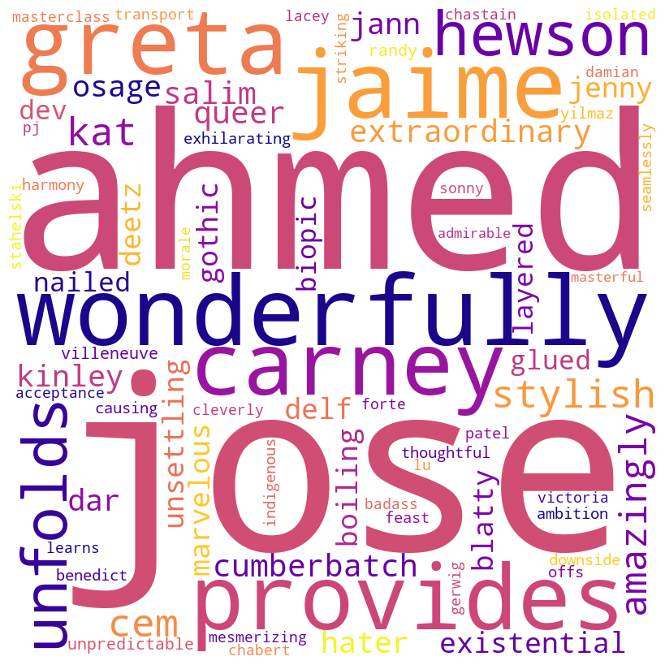

```python
texto_positivo_nube_tfidf = " "
for index, row in idf_positivos[(idf_positivos["tfidf"] >= 4.16) & (idf_positivos["unigrama"] != "na")].iterrows():
    palabra = row['unigrama']
    valores = row['valor']
    texto_positivo_nube_tfidf  += f'{palabra} ' * valores

nube_postivos_tfidf = WordCloud(width = 800, height = 800,
                collocations=False,
                background_color ='white',
                colormap='plasma',
                max_words = 75,
                min_font_size = 10).generate(texto_positivo_nube_tfidf)
plt.figure(figsize = (8, 8), facecolor = None)
plt.imshow(nube_postivos_tfidf)
plt.axis("off")
plt.tight_layout(pad = 0)
plt.show()
```

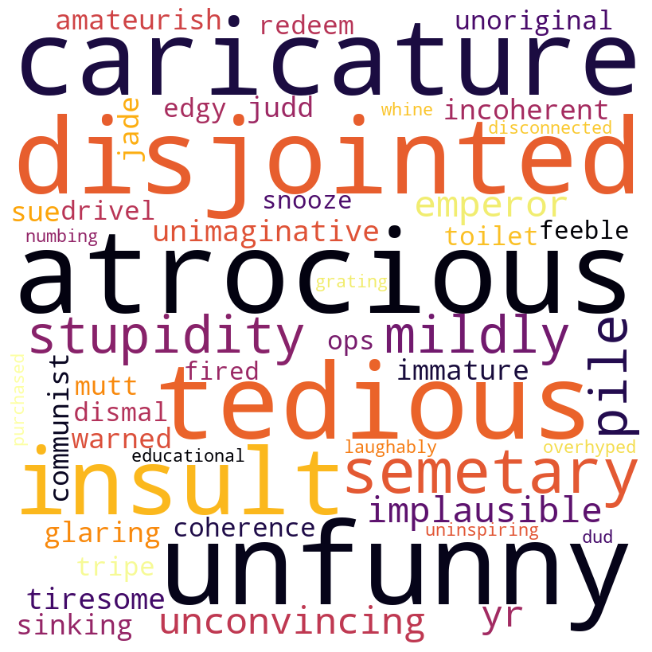

```python
texto_negativo_nube_tfidf = " "
for index, row in idf_negativos[(idf_negativos["tfidf"] >= 4.16) & (idf_negativos["unigrama"] != "na")].iterrows():
    palabra = row['unigrama']
    valores = row['valor']
    texto_negativo_nube_tfidf  += f'{palabra} ' * valores

nube_negativo_tfidf = WordCloud(width = 800, height = 800,
                collocations=False,
                background_color ='white',
                colormap='inferno',
                max_words = 75,
                min_font_size = 10).generate(texto_negativo_nube_tfidf)
plt.figure(figsize = (8, 8), facecolor = None)
plt.imshow(nube_negativo_tfidf)
plt.axis("off")
plt.tight_layout(pad = 0)
plt.show()
```

### Bigramas

En el caso particular cuando $n=2$, los n-gramas se denominan **bigramas**. A continuación, se calculan los pares de palabras más frecuentes para las reseñas positivas y negativas.

```python
#Bigramas más frecuentes
bigramas_positivos = Counter(nltk.bigrams(nltk.word_tokenize(texto_positivo)))
bigramas_negativos = Counter(nltk.bigrams(nltk.word_tokenize(texto_negativo)))

#Conjuntos de datos
bigramas_positivos_df = pd.DataFrame.from_dict(bigramas_positivos, orient='index').reset_index().rename(columns={'index':'bigrama', 0:'valor'})
for i in range(len(bigramas_positivos_df)):
    bigramas_positivos_df['bigrama'][i] = ' '.join(bigramas_positivos_df['bigrama'][i])
    pass
bigramas_positivos_df[["from", "to"]]= bigramas_positivos_df["bigrama"].str.split(' ', expand=True)


bigramas_negativos_df = pd.DataFrame.from_dict(bigramas_negativos, orient='index').reset_index().rename(columns={'index':'bigrama', 0:'valor'})
for i in range(len(bigramas_negativos_df)):
    bigramas_negativos_df['bigrama'][i] = ' '.join(bigramas_negativos_df['bigrama'][i])
    pass
bigramas_negativos_df[["from", "to"]]= bigramas_negativos_df["bigrama"].str.split(' ', expand=True)
```

En lugar de nubes de palabras, se realizan gráficos de red para visualizar los pares de palabras más comunes en reseñas positivas y negativas.

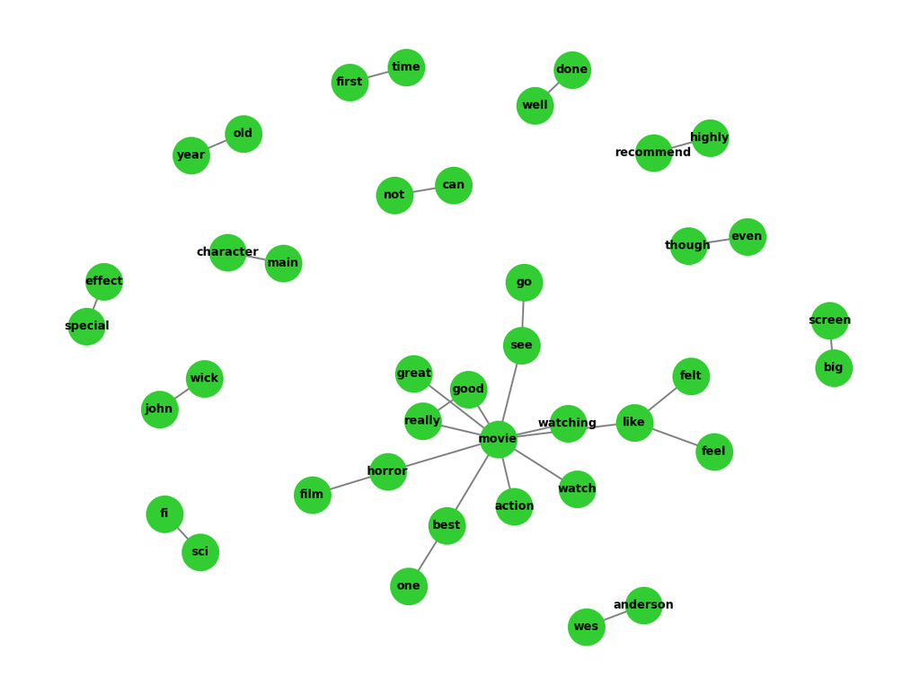

```python
plt.figure(figsize=(6.4 * 1.7, 4.8 * 1.7))

G=nx.from_pandas_edgelist(bigramas_positivos_df[bigramas_positivos_df["valor"]>=40], 'from', 'to')
nx.draw(G,
        with_labels=True,
        font_size = 10, font_weight="bold",
        node_color = "limegreen", node_size=1000,
        width=1.5, edge_color="grey", style="solid"
        )

plt.show()
```

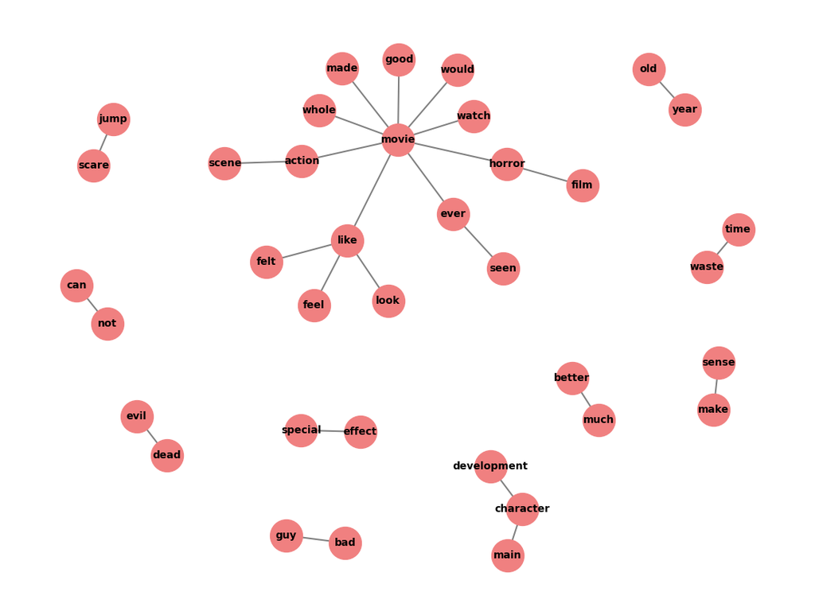

```python
plt.figure(figsize=(6.4 * 1.7, 4.8 * 1.7))

G=nx.from_pandas_edgelist(bigramas_negativos_df[bigramas_negativos_df["valor"]>=35], 'from', 'to')
nx.draw(G,
        with_labels=True,
        font_size = 10, font_weight="bold",
        node_color = "lightcoral", node_size=1000,
        width=1.5, edge_color="grey", style="solid"
        )

plt.show()
```

### Bigramas con TF-IDF

La estadística TF-IDF también puede calcularse para bigramas. Para ello, se considera cada par de palabras como un único término y se procede de manera análoga a lo realizado anteriormente.

```python
#Cadenas de palabras - TFIDF

    #Matriz
tfidf_cadena = TfidfVectorizer(ngram_range=(2,2), smooth_idf=False, norm=None)
matriz_cadena = tfidf_cadena.fit_transform(texto_corpus)

    #Datasets
idf_full_bigrama = pd.DataFrame({
    'bigrama': tfidf_cadena.get_feature_names_out(),
    'idf': abs(1 - tfidf_cadena.idf_)
})

idf_positivos_bigrama = pd.merge(idf_full_bigrama, bigramas_positivos_df, on='bigrama', how='right')
idf_negativos_bigrama = pd.merge(idf_full_bigrama, bigramas_negativos_df, on='bigrama', how='right')
idf_positivos_bigrama["tfidf"] = idf_positivos_bigrama["idf"]*idf_positivos_bigrama["valor"]
idf_negativos_bigrama["tfidf"] = idf_negativos_bigrama["idf"]*idf_negativos_bigrama["valor"]
```

Se grafican los bigramas con mayores valores de TF-IDF en reseñas positivas y negativas.

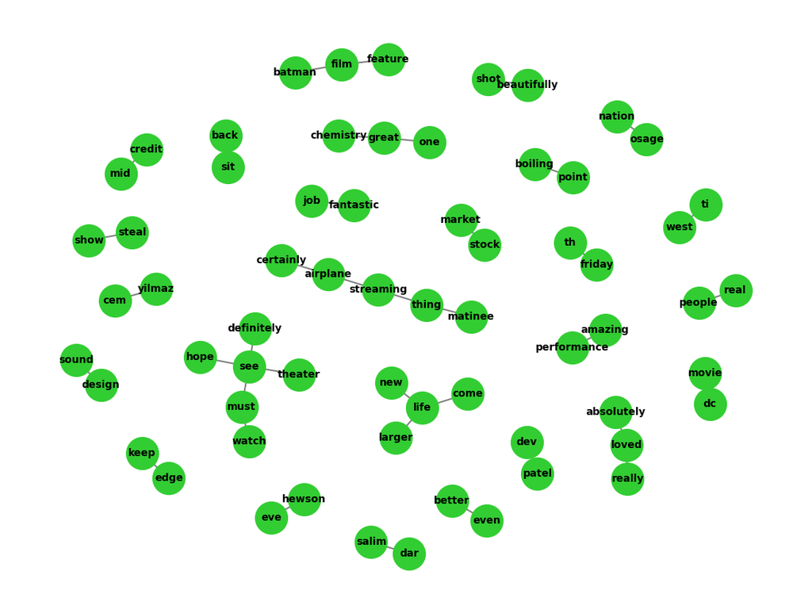

```python
plt.figure(figsize=(6.4 * 1.7, 4.8 * 1.7))

G=nx.from_pandas_edgelist(idf_positivos_bigrama[idf_positivos_bigrama["tfidf"]>=6], 'from', 'to')
nx.draw(G,
        with_labels=True,
        font_size = 10, font_weight="bold",
        node_color = "limegreen", node_size=1000,
        width=1.5, edge_color="grey", style="solid"
        )

plt.show()
```

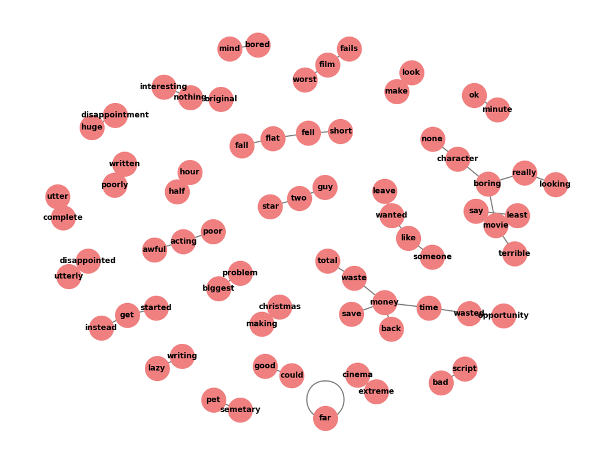

```python
plt.figure(figsize=(6.4 * 1.7, 4.8 * 1.7))

G=nx.from_pandas_edgelist(idf_negativos_bigrama[idf_negativos_bigrama["tfidf"]>=4.16], 'from', 'to')
nx.draw(G,
        with_labels=True,
        font_size = 10, font_weight="bold",
        node_color = "lightcoral", node_size=1000,
        width=1.5, edge_color="grey", style="solid"
        )

plt.show()
```

### Conversión a matriz de términos

Finalmente, para poder realizar el ajuste de los modelos, los conjuntos de datos son convertidos a [matrices término-documento](https://en.wikipedia.org/wiki/Document-term_matrix) (DTM).

```python
#Construcción de matrices

    #Matriz con unigramas
cv = CountVectorizer()

matriz_unigramas = cv.fit_transform(datos['texto_limpio'])

    #Matriz con unigramas TF-IDF
tfidf = TfidfVectorizer()

matriz_tfidf_unigramas = tfidf.fit_transform(datos['texto_limpio'])

    #Matriz con bigramas
bigram_vectorizer = CountVectorizer(ngram_range=(2,2))

matriz_bigramas = bigram_vectorizer.fit_transform(datos['texto_limpio'])

    #Matriz con bigramas y TF-IDF
bigram_tfidf = TfidfVectorizer(ngram_range=(2,2))

matriz_tfidf_bigramas = bigram_tfidf.fit_transform(datos['texto_limpio'])

#Guardar matrices
scipy.sparse.save_npz("D:\Python\Textos\matriz_unigramas",matriz_unigramas)
scipy.sparse.save_npz("D:\Python\Textos\matriz_tfidf_unigramas",matriz_tfidf_unigramas)
scipy.sparse.save_npz("D:\Python\Textos\matriz_bigramas",matriz_bigramas)
scipy.sparse.save_npz("D:\Python\Textos\matriz_tfidf_bigramas",matriz_tfidf_bigramas)
```

## 4) Ajuste de modelos

En esta sección se aplican distintas técnicas de aprendizaje supervisado para cada uno de los escenarios anteriores.

```python
#Importar bibliotecas necesarias
from sklearn.model_selection import train_test_split
from sklearn.linear_model import LogisticRegression
from sklearn.naive_bayes import MultinomialNB
from sklearn.tree import DecisionTreeClassifier
from sklearn.ensemble import RandomForestClassifier
from sklearn import metrics
from sklearn.metrics import accuracy_score, classification_report
from skopt.space import Integer
from skopt import BayesSearchCV

#Cargar datos
datos = pd.read_csv(r'D:/Python/Textos/datos.csv')

matriz_unigramas = scipy.sparse.load_npz("D:\Python\Textos\matriz_unigramas.npz")
matriz_tfidf_unigramas = scipy.sparse.load_npz("D:\Python\Textos\matriz_tfidf_unigramas.npz")
matriz_bigramas = scipy.sparse.load_npz("D:\Python\Textos\matriz_bigramas.npz")
matriz_tfidf_bigramas = scipy.sparse.load_npz("D:\Python\Textos\matriz_tfidf_bigramas.npz")
```

Se comienza dividiendo al conjunto de datos en un conjunto de entrenamiento y un conjunto de prueba. A continuación, se define una función para implementar los distintos algoritmos usando las cuatro matrices guardadas previamente. La función también calcula la precisión (o exactitud) global obtenida y otras medidas para evaluar los modelos.

```python
#Datos
matrices = [matriz_unigramas, matriz_tfidf_unigramas, matriz_bigramas, matriz_tfidf_bigramas] #Matriz a utilizar
nombres = ["1) Unigramas y TF", "2) Unigramas y TF-IDF", "3) Bigramas y TF", "4) Bigramas y TF-IDF" ] #Escenario
accuracies = [] #Precisión obtenida

#División en conjuntos de entrenamiento y prueba
X = datos["id"] - 1
y = datos["tipo"]
X_train, X_test, y_train, y_test = train_test_split(X, y, test_size=0.33, random_state=30062000)
print('Conjunto de entrenamiento:', X_train.shape)
print('Conjunto de prueba: ', X_test.shape)


#Función para ajustar un modelo y devolver métricas
def ajuste_modelo(modelo):
    for matriz, nombre in zip(matrices, nombres):

        modelo.fit(matriz[X_train], y_train)

        predicciones = modelo.predict(matriz[X_test])

        matriz_confusion = pd.DataFrame(metrics.confusion_matrix(y_test,predicciones), index=['positiva','negativa'], columns=['positiva','negativa'])
        accuracies.append(accuracy_score(y_test, predicciones))

        print("Escenario: " + nombre)
        print("Precisión: ")
        print(accuracy_score(y_test, predicciones ))
        print(matriz_confusion)
        print("Medidas para evaluar:")
        print(classification_report(y_test, predicciones ))
        pass
    pass
```

```
Conjunto de entrenamiento: (1553,)
Conjunto de prueba:  (765,)
```

### Regresión logística

```python
lr = LogisticRegression()

ajuste_modelo(lr)
```

```
Escenario: 1) Unigramas y TF
Precisión:
0.8718954248366013
          positiva  negativa
positiva       327        62
negativa        36       340
Medidas para evaluar:
              precision    recall  f1-score   support

    negativa       0.90      0.84      0.87       389
    positiva       0.85      0.90      0.87       376

    accuracy                           0.87       765
   macro avg       0.87      0.87      0.87       765
weighted avg       0.87      0.87      0.87       765

Escenario: 2) Unigramas y TF-IDF
Precisión:
0.8941176470588236
          positiva  negativa
positiva       328        61
negativa        20       356
Medidas para evaluar:
              precision    recall  f1-score   support

    negativa       0.94      0.84      0.89       389
    positiva       0.85      0.95      0.90       376

    accuracy                           0.89       765
   macro avg       0.90      0.89      0.89       765
weighted avg       0.90      0.89      0.89       765

Escenario: 3) Bigramas y TF
Precisión:
0.7803921568627451
          positiva  negativa
positiva       276       113
negativa        55       321
Medidas para evaluar:
              precision    recall  f1-score   support
```

[output cut: 8 more lines]

```
Escenario: 4) Bigramas y TF-IDF
Precisión:
0.5450980392156862
          positiva  negativa
positiva        41       348
negativa         0       376
Medidas para evaluar:
              precision    recall  f1-score   support

    negativa       1.00      0.11      0.19       389
    positiva       0.52      1.00      0.68       376

    accuracy                           0.55       765
   macro avg       0.76      0.55      0.44       765
weighted avg       0.76      0.55      0.43       765
```

### Clasificador bayesiano ingenuo

```python
nv = MultinomialNB()

ajuste_modelo(nv)
```

```
Escenario: 1) Unigramas y TF
Precisión:
0.8718954248366013
          positiva  negativa
positiva       338        51
negativa        47       329
Medidas para evaluar:
              precision    recall  f1-score   support

    negativa       0.88      0.87      0.87       389
    positiva       0.87      0.88      0.87       376

    accuracy                           0.87       765
   macro avg       0.87      0.87      0.87       765
weighted avg       0.87      0.87      0.87       765

Escenario: 2) Unigramas y TF-IDF
Precisión:
0.7686274509803922
          positiva  negativa
positiva       216       173
negativa         4       372
Medidas para evaluar:
              precision    recall  f1-score   support

    negativa       0.98      0.56      0.71       389
    positiva       0.68      0.99      0.81       376

    accuracy                           0.77       765
   macro avg       0.83      0.77      0.76       765
weighted avg       0.83      0.77      0.76       765

Escenario: 3) Bigramas y TF
Precisión:
0.807843137254902
          positiva  negativa
positiva       348        41
negativa       106       270
Medidas para evaluar:
              precision    recall  f1-score   support
```

[output cut: 8 more lines]

```
Escenario: 4) Bigramas y TF-IDF
Precisión:
0.6169934640522876
          positiva  negativa
positiva        98       291
negativa         2       374
Medidas para evaluar:
              precision    recall  f1-score   support

    negativa       0.98      0.25      0.40       389
    positiva       0.56      0.99      0.72       376

    accuracy                           0.62       765
   macro avg       0.77      0.62      0.56       765
weighted avg       0.77      0.62      0.56       765
```

### Árbol de decisión

```python
arbol = DecisionTreeClassifier()

ajuste_modelo(arbol)
```

```
Escenario: 1) Unigramas y TF
Precisión:
0.7163398692810458
          positiva  negativa
positiva       260       129
negativa        88       288
Medidas para evaluar:
              precision    recall  f1-score   support

    negativa       0.75      0.67      0.71       389
    positiva       0.69      0.77      0.73       376

    accuracy                           0.72       765
   macro avg       0.72      0.72      0.72       765
weighted avg       0.72      0.72      0.72       765

Escenario: 2) Unigramas y TF-IDF
Precisión:
0.6954248366013072
          positiva  negativa
positiva       256       133
negativa       100       276
Medidas para evaluar:
              precision    recall  f1-score   support

    negativa       0.72      0.66      0.69       389
    positiva       0.67      0.73      0.70       376

    accuracy                           0.70       765
   macro avg       0.70      0.70      0.70       765
weighted avg       0.70      0.70      0.70       765

Escenario: 3) Bigramas y TF
Precisión:
0.6967320261437908
          positiva  negativa
positiva       314        75
negativa       157       219
Medidas para evaluar:
              precision    recall  f1-score   support
```

[output cut: 8 more lines]

```
Escenario: 4) Bigramas y TF-IDF
Precisión:
0.6862745098039216
          positiva  negativa
positiva       295        94
negativa       146       230
Medidas para evaluar:
              precision    recall  f1-score   support

    negativa       0.67      0.76      0.71       389
    positiva       0.71      0.61      0.66       376

    accuracy                           0.69       765
   macro avg       0.69      0.69      0.68       765
weighted avg       0.69      0.69      0.68       765
```

### Bosques aleatorios

Se aplica una optimización bayesiana para hallar los hiperparámetros ideales para bosques aleatorios. La búsqueda se realiza por separado para unigramas y para bigramas.

```python
space_unigrama  = {
    'n_estimators': Integer(100, 1000),
    'max_features': Integer(100,300),
}

space_bigrama  = {
    'n_estimators': Integer(100, 1000),
    'max_features': Integer(100,500),
}

busqueda_bayes_unigrama = BayesSearchCV(
    estimator=RandomForestClassifier(random_state=30062000),
    search_spaces=space_unigrama,
    n_iter=10,
    cv=3,
    scoring="accuracy"
  )

busqueda_bayes_bigrama = BayesSearchCV(
    estimator=RandomForestClassifier(random_state=30062000),
    search_spaces=space_bigrama,
    n_iter=10,
    cv=3,
    scoring="accuracy"
  )

np.int = int #Evita bug
```

Utilizando los hiperparámetros ideales para cada escenario, se ajustan los bosques aleatorios y se calculan medidas para evaluar los modelos.

```python
 #Unigramas y TF
busqueda_bayes_unigrama.fit(matriz_unigramas[X_train], y_train)

predicciones = busqueda_bayes_unigrama.predict(matriz_unigramas[X_test])

matriz_confusion = pd.DataFrame(metrics.confusion_matrix(y_test,predicciones), index=['positiva','negativa'], columns=['positiva','negativa'])
accuracies.append(accuracy_score(y_test, predicciones))

print("Escenario: Unigramas y TF")
print("Precisión: ")
print(accuracy_score(y_test, predicciones ))
print(matriz_confusion)
print("Medidas para evaluar:")
print(classification_report(y_test, predicciones ))
print("Mejores parámetros:")
print(busqueda_bayes_unigrama.best_params_)

#Unigramas y TF-IDF
busqueda_bayes_unigrama.fit(matriz_tfidf_unigramas[X_train], y_train)

predicciones = busqueda_bayes_unigrama.predict(matriz_tfidf_unigramas[X_test])

matriz_confusion = pd.DataFrame(metrics.confusion_matrix(y_test,predicciones), index=['positiva','negativa'], columns=['positiva','negativa'])
accuracies.append(accuracy_score(y_test, predicciones))

print("Escenario: Unigramas y TF-IDF")
print("Precisión: ")
print(accuracy_score(y_test, predicciones ))
print(matriz_confusion)
print("Medidas para evaluar:")
print(classification_report(y_test, predicciones ))
print("Mejores parámetros:")
print(busqueda_bayes_unigrama.best_params_)

#Bigramas y TF
busqueda_bayes_bigrama.fit(matriz_bigramas[X_train], y_train)

predicciones = busqueda_bayes_bigrama.predict(matriz_bigramas[X_test])

matriz_confusion = pd.DataFrame(metrics.confusion_matrix(y_test,predicciones), index=['positiva','negativa'], columns=['positiva','negativa'])
accuracies.append(accuracy_score(y_test, predicciones))

print("Escenario: Bigramas y TF")
print("Precisión: ")
print(accuracy_score(y_test, predicciones ))
print(matriz_confusion)
print("Medidas para evaluar:")
print(classification_report(y_test, predicciones ))
print("Mejores parámetros:")
print(busqueda_bayes_bigrama.best_params_)

#Bigramas y TF-IDF
busqueda_bayes_bigrama.fit(matriz_tfidf_bigramas[X_train], y_train)

predicciones = busqueda_bayes_bigrama.predict(matriz_tfidf_bigramas[X_test])

matriz_confusion = pd.DataFrame(metrics.confusion_matrix(y_test,predicciones), index=['positiva','negativa'], columns=['positiva','negativa'])
accuracies.append(accuracy_score(y_test, predicciones))

print("Escenario: Bigramas y TF")
print("Precisión: ")
print(accuracy_score(y_test, predicciones ))
print(matriz_confusion)
print("Medidas para evaluar:")
print(classification_report(y_test, predicciones ))
print("Mejores parámetros:")
print(busqueda_bayes_bigrama.best_params_)
```

[output not shown]

### Guardar resultados

Se guardan los resultados en un archivo de Excel, registrando la técnica utilizada, el escenario de análisis y la precisión global obtenida.

```python
tecnicas_nombre = ["Regresión logística", "Naive Bayes", "Árbol de decisión", "Bosque aleatorio"]
tecnicas = []
for tecnica in tecnicas_nombre:
    tecnicas.extend([tecnica] * 4)

tabla = {'Técnica': tecnicas,
        'Escenario': nombres *4,
        'Precisión': accuracies}
tabla_df = pd.DataFrame(tabla)
tabla_df.to_excel('tabla_precision.xlsx')
```

## 5) Resultados y evaluación del modelo

En esta sección se analizan los resultados obtenidos previamente, se elige el mejor modelo y se calculan medidas para evaluarlo.

```python
#Importar bibliotecas necesarias
import seaborn as sns
from sklearn.metrics import precision_score, recall_score, f1_score

#Cargar datos
precision = pd.read_excel(r'D:/Python/Textos/tabla_precision.xlsx')
```

A continuación se muestra la precisión obtenida según técnica y escenario. En general, los mejores resultados se obtuvieron para el escenario 1 (unigramas y frecuencia de términos) y para regresión logística. Sin embargo, la mayor exactitud (89,41%) se obtuvo utilizando TF-IDF. Los peores valores, en general, se observaron en el escenario 4 (Bigramas y TF-IDF).

[figure not shown]

```python
precision["Precisión"] = precision["Precisión"].apply(lambda x: round(x* 100, 3)  )
tabla = precision.pivot(index="Escenario", columns="Técnica", values="Precisión")
mapa = sns.heatmap(tabla, annot=True, cmap='RdYlGn', linewidth=.5, fmt=".2f")
for t in mapa.texts: t.set_text(t.get_text() + " %")
mapa
```

Se selecciona el mejor escenario (unigramas, TF-IDF y regresión logística). Se calculan la precisión y exhaustividad (*recall*) para cada tipo de reseña, así como el valor de exactitud (*accuracy*) del modelo. Además, se grafica la matriz de confusión observada, en la cual las filas corresponden a los valores verdaderos mientras que las columnas a los valores predichos.

```
              precision    recall  f1-score   support

    negativa       0.94      0.84      0.89       389
    positiva       0.85      0.95      0.90       376

    accuracy                           0.89       765
   macro avg       0.90      0.89      0.89       765
weighted avg       0.90      0.89      0.89       765

Matriz de confusión
```

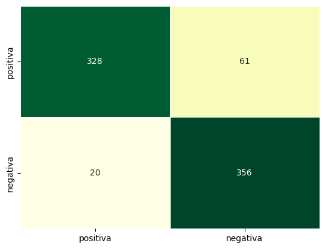

```python
#Métricas
lr.fit(matriz_tfidf_unigramas[X_train], y_train)
predicciones = lr.predict(matriz_tfidf_unigramas[X_test])

print( classification_report(y_test, predicciones) )
accuracy = accuracy_score(y_test, predicciones)
precision = precision_score(y_test, predicciones, pos_label='positiva')
recall = recall_score(y_test, predicciones, pos_label='positiva')
f1 = f1_score(y_test, predicciones, pos_label='positiva')

#Matriz de confusión
print("Matriz de confusión")
matriz_confusion = pd.DataFrame(metrics.confusion_matrix(y_test,predicciones), index=['positiva','negativa'], columns=['positiva','negativa'])
sns.heatmap(matriz_confusion, annot=True, cmap="YlGn", linewidth=.5,fmt=".0f", cbar=False)
```